# Analysis and visualizations of my Facebook Messenger chat data

```python
import pandas as pd
from numpy import int64, polyfit, nan
from math import floor, ceil
import matplotlib.pyplot as plt
from wordcloud import WordCloud
%matplotlib inline
my_name = 'Andreas Vija'
```

```python
csv_msgs = pd.read_csv('data.csv').fillna('')
csv_msgs.info()
csv_msgs.head()
```

```
<class 'pandas.core.frame.DataFrame'>
RangeIndex: 224665 entries, 0 to 224664
Data columns (total 6 columns):
groupchat    224665 non-null bool
thread       224665 non-null object
names        224665 non-null object
sender       224665 non-null object
time         224665 non-null int64
text         224665 non-null object
dtypes: bool(1), int64(1), object(4)
memory usage: 5.4+ MB
```

|  | groupchat | time | text |
| --- | --- | --- | --- |
| 0 | True | 1468449180 | I'm going to play baseball |
| 1 | True | 1468448040 | We cn do some |
| 2 | True | 1468447920 | I mean lifting weights? |
| 3 | True | 1468447920 | Yea |
| 4 | True | 1468447800 | Because I do |

```python
all_msgs = csv_msgs.copy()
all_msgs['time'] = csv_msgs['time'].astype('datetime64[s]')
```

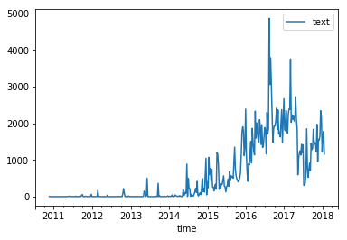

```python
df = all_msgs[['time', 'text']]
df = df.set_index('time')
df = df.resample('w').count()

df.plot();
```

Only <5% of my messages were sent before 2015, thus leaving out 2010-2014 helps make some graphs easier to read while losing very little data

```python
most_msgs = csv_msgs.copy()
_2015 = pd.to_datetime('2015-01-01 00:00:00', infer_datetime_format=True).timestamp()
most_msgs = most_msgs[most_msgs['time'] > int(_2015)]
most_msgs['time'] = most_msgs['time'].astype('datetime64[s]')
```

## Chats with the most messages

As evident later in certain "chat activity over time" graphs, big chunks of messages are actually missing from multiple chats, making these message counts not accurate, although they paint a fair enough picture of the most active chats

```python
chats = all_msgs.copy()[['thread', 'names', 'groupchat']].groupby(['thread', 'names'], as_index=False)

types = chats.max()[['groupchat']]
counts = chats.count().rename(columns={'groupchat': 'message count'})
chats = pd.concat([types, counts], axis=1)

chats = chats.sort_values('message count', ascending=False)
chats = chats.reset_index()[['thread', 'groupchat', 'names', 'message count']]

chats[['thread', 'groupchat', 'message count']].head(20)
```

|  | groupchat | message count |
| --- | --- | --- |
| 0 | False | 72350 |
| 1 | True | 17419 |
| 2 | True | 11774 |
| 3 | True | 10000 |
| 4 | True | 10000 |
| 5 | False | 10000 |
| 6 | False | 9998 |
| 7 | False | 9997 |
| 8 | False | 6229 |
| 9 | False | 5523 |
| 10 | True | 5275 |
| 11 | True | 3863 |
| 12 | True | 3851 |
| 13 | True | 2526 |
| 14 | True | 2462 |
| 15 | True | 1964 |
| 16 | True | 1835 |
| 17 | False | 1712 |
| 18 | True | 1645 |
| 19 | False | 1580 |

5 chats with exactly/almost exactly 10,000 messages is suspicious

## People with the most messages in this dataset

```python
df = all_msgs.copy()[['sender', 'groupchat']]
df = df.groupby('sender').count()
df = df.rename(columns={'groupchat': 'messages_available'})
df = df.sort_values('messages_available', ascending = False)
df.head(20)
```

|  | messages_available |
| --- | --- |
| 0 | 75853 |
| 1 | 37881 |
| 2 | 12771 |
| 3 | 10763 |
| 4 | 9691 |
| 5 | 8861 |
| 6 | 6388 |
| 7 | 3111 |
| 8 | 3110 |
| 9 | 2861 |
| 10 | 2093 |
| 11 | 1606 |
| 12 | 1571 |
| 13 | 1501 |
| 14 | 1383 |
| 15 | 1365 |
| 16 | 1339 |
| 17 | 1308 |
| 18 | 1258 |
| 19 | 1199 |

## The activity I have recorded in various chat types through time

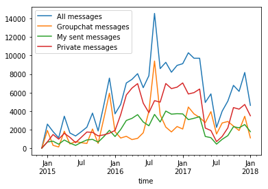

```python
df1 = most_msgs.copy()
df1 = df1.set_index('time')

df2 = df1[df1['groupchat'] == True]
df3 = df1[df1['groupchat'] == False]
df4 = df1[df1['sender'] == my_name]

df1 = df1[['text']]
df2 = df2[['text']]
df3 = df3[['text']]
df4 = df4[['text']]

df1 = df1.rename(columns={'text': 'All messages'})
df2 = df2.rename(columns={'text': 'Groupchat messages'})
df3 = df3.rename(columns={'text': 'Private messages'})
df4 = df4.rename(columns={'text': 'My sent messages'})

df1 = pd.concat([df1, df2, df3, df4])
df1 = df1.resample('M').count()

df1.plot();
```

- The peak in late 2015 is a new groupchat with two of my friends, the following dip and the continued low of groupchat messages is roughly 10k missing messages from the same chat and many messages missing from another groupchat.
- The peak in Jul-Aug 2016 is the groupchat of a high school summer program in USA
- The general low in Apr-Aug 2017 is roughly 10k missing messages from a single private conversation

## My activity by the time of day

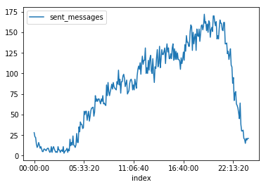

```python
df = all_msgs[all_msgs['sender'] == my_name]
df = df[['time', 'groupchat']]

df = df.set_index('time')
df = df.resample('5min').sum()
df.index = df.index.time
df = df.reset_index()

df = df.groupby('index')
df = df.count()
df = df.rename(columns={'groupchat': 'sent_messages'})

df.plot();
```

## Messages by time of day every day

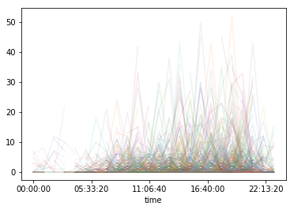

```python
df = all_msgs[all_msgs['sender'] == my_name]
df = df[['time', 'groupchat']]
df = df.set_index('time')
df = df.resample('H').sum()
pivot = df.pivot_table('groupchat', index=df.index.time, columns=df.index.date)
pivot.plot(legend=False, alpha=0.10);
```

There does not seem to be any consistent baseline, most activity seems to come in spikes

## My activity by the day of the week

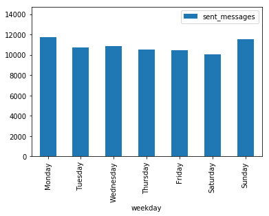

```python
df1 = all_msgs[all_msgs['sender'] == my_name]
df1 = df1[['time', 'groupchat']]
df1 = df1.rename(columns={'groupchat': 'sent_messages', 'time': 'weekday'})
df1 = df1.set_index('weekday')

df2 = df1.copy()
df2['weekday_number'] = df2.index.weekday
df2 = df2[['weekday_number']]

df1.index = df1.index.weekday_name
df2.index = df2.index.weekday_name

df1 = df1.groupby('weekday').count()
df2 = df2.groupby('weekday').max()

df1 = pd.concat([df1, df2], axis=1)

df1 = df1.sort_values('weekday_number')
df1 = df1[['sent_messages']]

maximum = df1['sent_messages'].values.max()
df1.plot(kind='bar', ylim=(0, maximum + 3000));
```

## Words per message I send over time

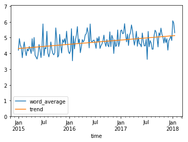

```python
df = most_msgs[most_msgs['sender'] == my_name]
df = df[['time', 'text']]
df['word_average'] = df['text'].str.strip().str.replace('  ', ' ').str.split(' ').apply(len)
df = df[['time', 'word_average']]

df = df.set_index('time')
df = df.resample('w').mean()
df = df.reset_index()

timestamps = df['time'].values.astype(int64) // 10 ** 9 #strange hack
a, b = polyfit(timestamps, df['word_average'], 1)

x = range(timestamps.min(), timestamps.max()+1, 604800) #604 800 seconds in a week
trend = pd.Series(a*x + b, name='trend')

df = pd.concat([df, trend], axis=1)
df = df.set_index('time')

maximum = df['word_average'].values.max()
df.plot(ylim=(0, maximum + 1));
```

## Relationship between messages in a chat and the average number of words in one message

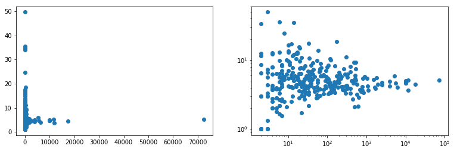

```python
df1 = all_msgs[['thread', 'text']]
df2 = df1.copy()

df1 = df1.rename(columns={'text': 'word_count'})
df1 = df1.groupby('thread').count()

df2['text'] = df2['text'].str.split(' ').apply(len)
df2 = df2.rename(columns={'text': 'word_average'})
df2 = df2.groupby('thread').mean()

df1 = pd.concat([df1, df2], axis=1)

f, axarr = plt.subplots(1, 2, figsize=(13,4))
axarr[0].scatter(x=df1['word_count'], y=df1['word_average'])
axarr[1].scatter(x=df1['word_count'], y=df1['word_average'])
axarr[1].set_yscale('log')
axarr[1].set_xscale('log')
```

As the amount of messages sent increases, the average words per message converges somewhere between 4 and 5.

## Most common words for all messages and for me

```python
words = dict()
punctuation = ['.',',',';','!','?',')']

def read_words(message):
    global words, punctuation
    wordlist = message.lower().strip().replace('\r', ' ').replace('\n', ' ').replace('  ', ' ').split(' ')

    for word in wordlist:

        while len(word) > 1 and word[-1] in punctuation:
            word = word[: len(word) - 1]
        while len(word) > 1 and word[0] == '(':
            word = word[1:]

        if word in words:
            words[word] = words.get(word) + 1
        else:
            words[word] = 1

def get_word_counts(df):
    global words, punctuation

    df['text'].apply(read_words)

    df = pd.DataFrame.from_dict(words, orient='index')
    words = dict()

    df.columns = ['count']
    df = df.sort_values('count', ascending=False)

    return df
```

```python
df1 = all_msgs[['text']]
df2 = (all_msgs[all_msgs['sender'] == my_name])[['text']]

df1 = get_word_counts(df1)
print(df1.head(20))
print()

df2 = get_word_counts(df2)
print(df2.head(20))

all_word_counts = df1.copy()
```

```
       count
ma     26939
on     25826
:d     22587
ei     22428
ja     18863
et     15278
       15061
aga    13943
see    13767
siis   11362
kui    10070
ka      9808
sa      8552
mis     6776
kas     6394
nii     5359
oli     5275
mul     5073
mingi   4871
seda    4724

      count
:d    10589
on    10087
ma     9213
ei     7868
ja     6721
aga    5472
et     4971
see    4918
siis   4080
sa     3846
kui    3655
       3201
ka     3173
mis    2556
kas    2130
oli    2057
seda   1734
pole   1702
mul    1646
nii    1616
```

Only significant differences are my fondness of ":D" and that I send non-text data (images, stickers, etc., represented by empty string) somewhat less.

## Acitivity of the biggest chats over time

```python
chats = chats.copy()

groupchats = chats[chats['groupchat'] == True]
chats = chats[chats['groupchat'] == False]
# 8 most popular groupchats and regular chats
important_chats = (chats[['thread', 'names']][:10].values.tolist() +
                   groupchats[['thread', 'names']][:10].values.tolist())
```

```python
queue = list() #contains tuples in the form (image or plot, title, optional plot type)

# helper function to arrange images more compactly
def display_queue_as_grid(figure_type, columns=3):

    rows = ceil(len(queue)/columns)

    for i in range(rows):
        f, axarr = plt.subplots(1, columns, figsize=(18,5))

        for j in range(columns):

            if len(queue) > 0:

                if figure_type == 'image':
                    data = queue.pop(0)
                    axarr[j].imshow(data[0], interpolation='bilinear')
                    axarr[j].set_axis_off()

                else:
                    data = queue.pop(0)
                    data[0].plot(kind=data[2], ax=axarr[j], title=title)

                axarr[j].set_title(data[1])

            else:
                axarr[j].set_axis_off()

        plt.show()
```

```python
def create_timeseries(messages, title, people):

    if len(people.split(',')) < 12 : # if there is <=12 people, including me
        # area plot with each person's contribution
        df1s = []
        people = people.split(',') + [my_name]

        for person in people:

            df1 = messages[messages['sender'] == person]
            df1 = df1.set_index('time')[['groupchat']].sort_index()
            df1 = df1.rename(columns={'groupchat': person})
            df1s.append(df1)

        timeseries = pd.concat(df1s)
        timeseries = timeseries.resample('M').count()
        queue.append((timeseries, title, 'area'))

    else:
        # just a simple timeseries of all sent messages
        timeseries = messages.set_index('time')[['groupchat']].sort_index()
        timeseries = timeseries.rename(columns={'groupchat': 'Sent messages'})
        timeseries = timeseries.resample('w').count()
        queue.append((timeseries, title, 'line'))
```

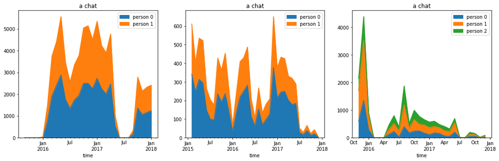

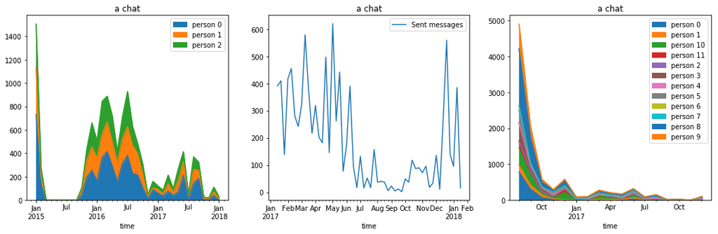

```python
for data in important_chats:
    thread = data[0]
    names = data[1]
    chat = all_msgs[all_msgs['thread'] == thread]
    chat = all_msgs[all_msgs['names'] == names]

    if len(thread) > 50:
        title = thread[:50] + '...'
    else:
        title = thread

    create_timeseries(chat, title, names)

display_queue_as_grid('plot')
```

- Missing chunks of messages can be observed in many chats here.
- Some chat data also starts later than the chats actually did.

## Average words per message by people in different chats

```python
def print_average_wpm(messages, title, people):

    averages = dict()

    if len(people.split(',')) > 12 :
        # if there is >12 people including me, skip it
        # because there are too many people to display
        return

    people = people.split(',') + [my_name]

    for person in people:

        df = messages[messages['sender'] == person]
        df2 = df.copy()
        df2['word_average'] = df2['text'].str.strip().str.replace('  ', ' ').str.split(' ').apply(len)
        df2 = df2[['word_average']]
        averages[person] = round(df2.mean(), 2)

    df = messages.copy()
    df['word_average'] = df['text'].str.strip().str.replace('  ', ' ').str.split(' ').apply(len)
    df = df[['word_average']]
    #averages['chat'] = round(df.mean(), 2)
    df = pd.DataFrame.from_dict(averages, orient='index')

    print('###' + title + ':' + '\n')
    print(df)
    print()
```

```python
for data in important_chats:
    thread = data[0]
    names = data[1]
    chat = all_msgs[all_msgs['thread'] == thread]
    chat = all_msgs[all_msgs['names'] == names]

    if len(thread) > 50:
        title = thread[:50] + '...'
    else:
        title = thread

    print_average_wpm(chat, title, names)
```

```
###a chat:

              word_average
person
Andreas Vija          5.13
1                     5.21

###a chat:

              word_average
person
Andreas Vija          4.62
1                     4.97

###a chat:

              word_average
person
Andreas Vija          3.15
1                     4.50
2                     1.92
3                     7.09
4                     5.58
5                     4.29
6                     4.56
7                     5.72
8                     3.90
9                     5.01
10                     NaN
11                    4.27
```

No significant data exists for other people, but as one might expect, my wordiness seems to depend greatly on the chat

## Most characteristic words of the biggest chats

(Calculated as words occurring much more often in the chat as compared to the entire dataset)

```python
important_word_counts = all_word_counts[all_word_counts['count'] >= 6]
total_important_words = all_word_counts['count'].sum()
word_frequencies = important_word_counts['count'] / total_important_words
word_frequencies = word_frequencies.rename('global_frequency')

def remove_longs(word):
    # get rid of very long words such as URLs that ruin wordcluds
    if len(word) < 18:
        return word
    else:
        return nan

def plot_most_characteristic_words(messages, title):
    df = get_word_counts(messages)

    df['frequency'] = df['count'] / df['count'].sum()
    df = df[df['count'] >= 6]

    df = pd.concat([df, word_frequencies], axis=1)
    # drop all columns where there isn't a value in 'frequency'
    df = df.dropna(axis=0, how='any')

    df['quotient'] = df['frequency'] / df['global_frequency']
    df['word'] = df.index.to_series().apply(remove_longs)
    df = df.dropna(axis=0, how='any')
    df = df.set_index('word')

    df = df.sort_values(['quotient', 'count'], ascending=[False, False])
    df = df[['quotient']].head(80)

    dictionary = df['quotient'].to_dict()
    wordcloud = WordCloud(height=300, width=400, max_font_size=55).generate_from_frequencies(dictionary)

    queue.append((wordcloud, title))
```

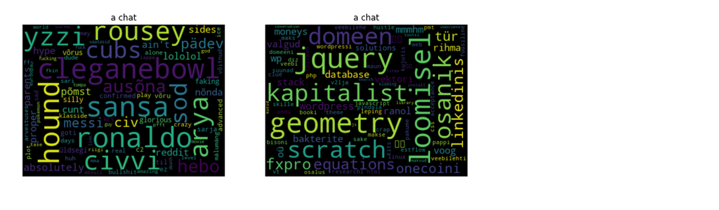

```python
for data in important_chats:
    thread = data[0]
    names = data[1]
    chat = all_msgs[all_msgs['thread'] == thread]
    chat = all_msgs[all_msgs['names'] == names]

    if len(thread) > 50:
        title = thread[:50] + '...'
    else:
        title = thread

    plot_most_characteristic_words(chat, title)

display_queue_as_grid('image')
```

## Most characteristic words of the most occurring people

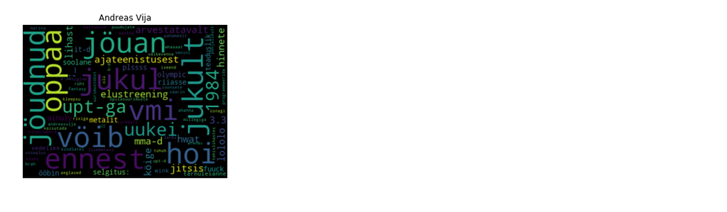

```python
df = all_msgs.copy()[['sender', 'groupchat']]
df = df.groupby('sender').count()
df = df.rename(columns={'groupchat': 'messages_available'})
df = df.sort_values('messages_available', ascending = False)
most_occurring_people = df[df['messages_available'] >= 500].index.tolist()

for person in most_occurring_people[:20]:
    messages = all_msgs[all_msgs['sender'] == person]
    plot_most_characteristic_words(messages, person)

display_queue_as_grid('image')
```